# Turismo emisivo

Julio 2022

## Introducción

- Se trabajó con la última base de turismo emisivo, publicada por el Ministerio de Turismo.
- Comprende información acerca del turismo en el exterior entre diciembre de 2016 y marzo de 2020.
- La base de datos original consta de 16.295 observaciones y 41 variables numéricas, categóricas y de identificación.
- Dado que se trata de una encuesta, dos de esas variables corresponden a juegos de ponderadores. Aunque en este trabajo se optó por no expandir la muestra, es importante tener en cuenta que esto puede introducir sesgos en las estimaciones.

## Objetivos

- Analizar al gasto por día y por persona de los turistas uruguayos en el exterior. En particular, se estudió su evolución entre enero de 2017 y marzo de 2020, desagregado por distintos rubros.
- Indagar sobre la existencia de posibles asociaciones entre el gasto y diferentes variables categóricas como, por ejemplo, el destino y el motivo del viaje.

## Variables

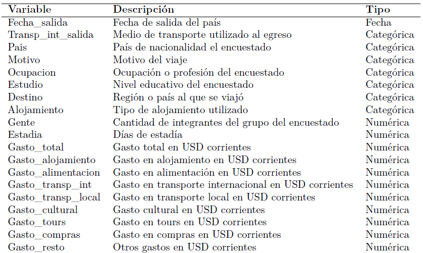

## Selección de observaciones

- Se filtró a los turistas que, si bien salieron de Uruguay, no tienen nacionalidad uruguaya.
- Para facilitar la visualización, se eliminó un *outlier*, cuyo gasto total era extremadamente alto.
- No se eliminaron los individuos que reportaron gastos nulos ya que, en su mayoría, son personas que fueron a visitar familiares y/o amigos y se alojaron con ellos, por lo que no debieron incurrir en gastos.

## Observaciones atípicas

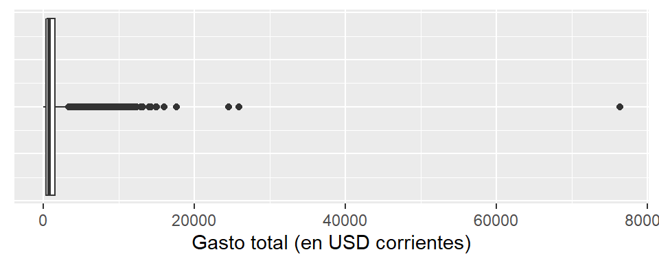

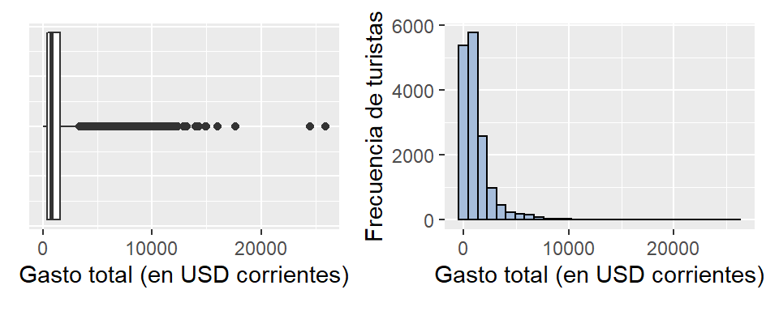

## Gastos nulos

Gasto nulo según tipo de alojamiento

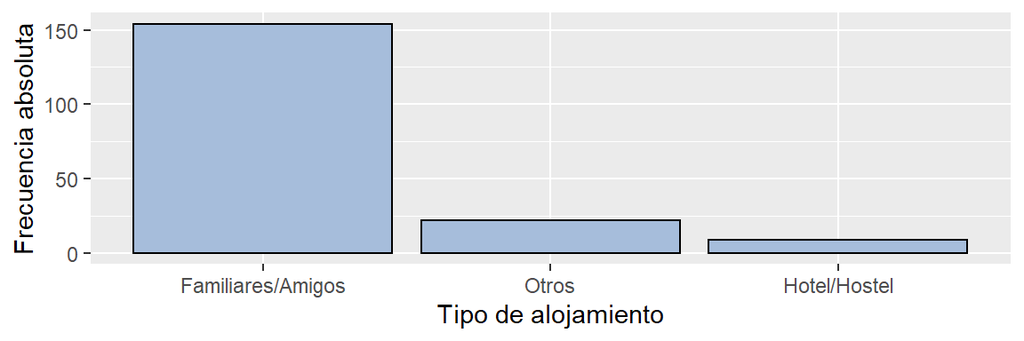

Gasto nulo según motivo de viaje

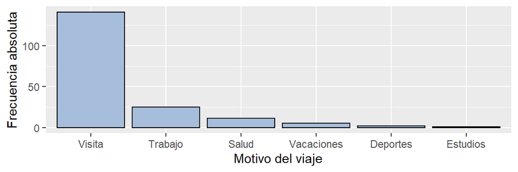

## Gasto total

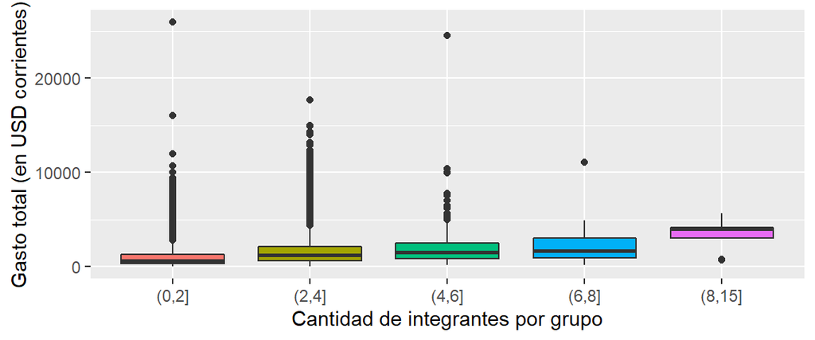

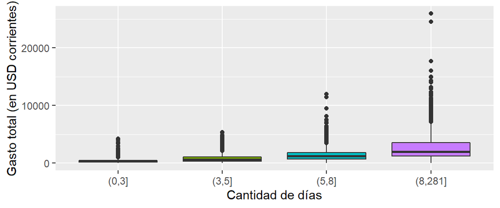

## Evolución de la cantidad de salidas

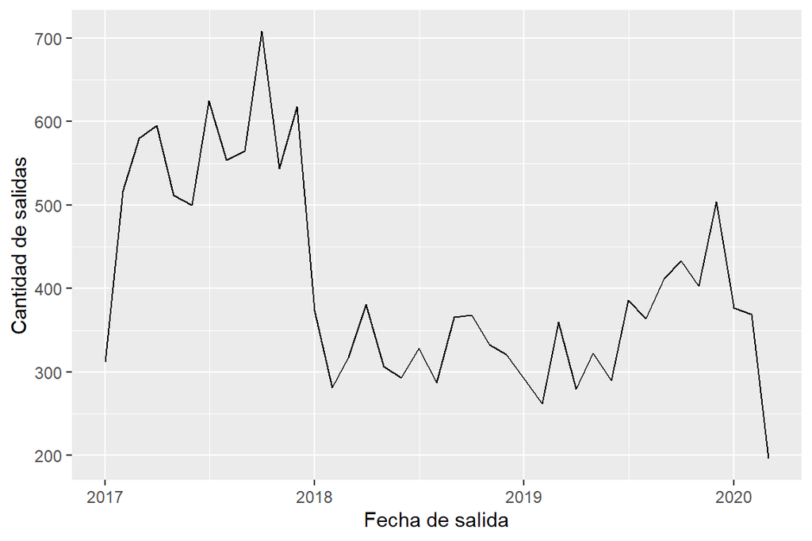

## Evolución del gasto (USD corrientes)

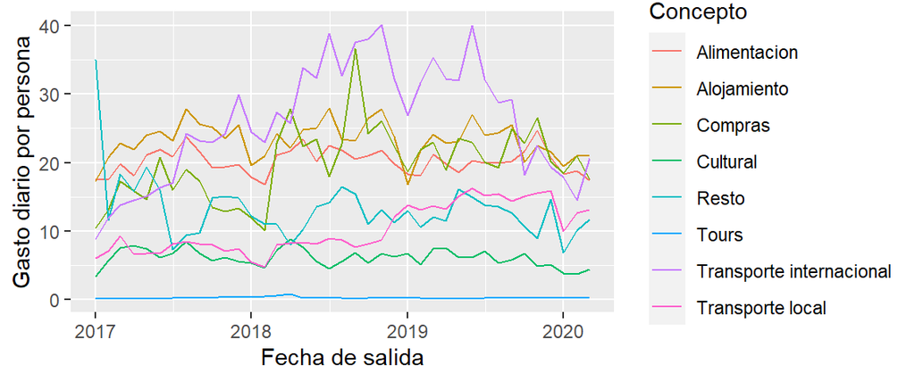

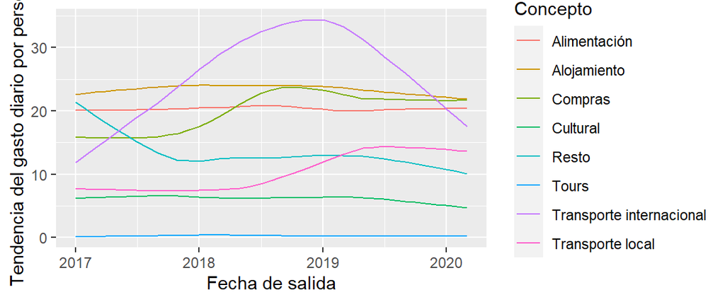

## Distribución del gasto (USD corrientes)

Distribución del gasto por destino

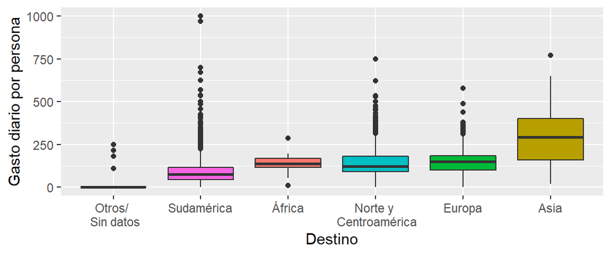

Distribución del gasto por nivel educativo

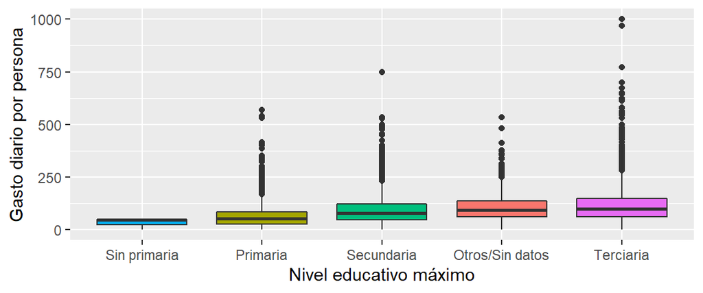

## Distribución del gasto (USD corrientes)

Distribución del gasto por ocupación

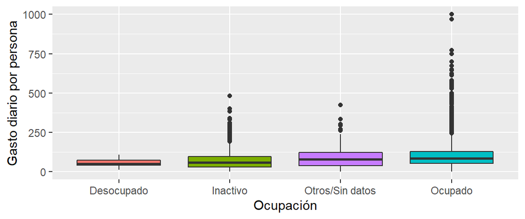

Distribución del gasto por tipo de alojamiento

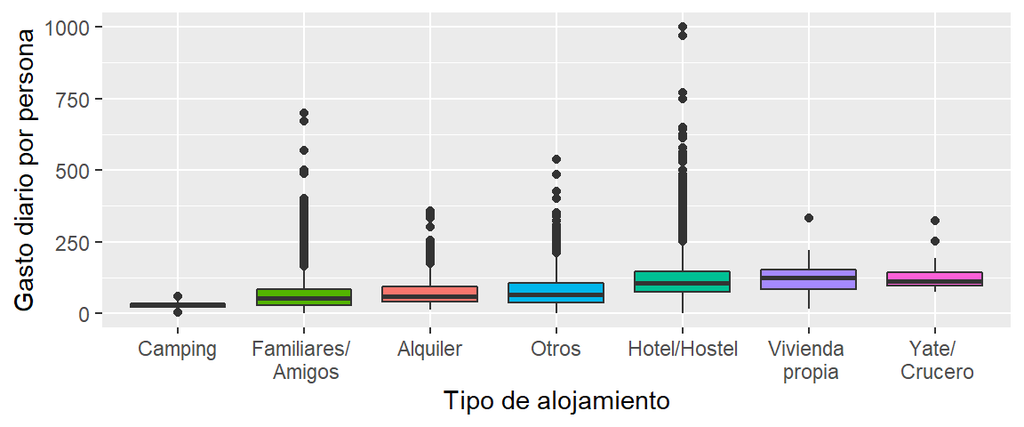

## Conclusiones

- Al analizar el gasto medio diario por persona en función de distintas variables categóricas, se concluye que:
  - La región de destino más costosa es Asia. Sin embargo, existen varios datos inusualmente altos entre quienes viajan a otras partes del mundo.
  - A mayor nivel educativo del encuestado, mayor tiende a ser el gasto total.
  - Los individuos ocupados tienden a gastar más que los desempleados y los inactivos.
  - Quienes viajan para visitar a familiares tienden a gastar menos. Esto se debe a que, con frecuencia, se evitan los costos de alojamiento.
- Los principales resultados del trabajo se resumen en la [Shiny](https://patriciamartell.shinyapps.io/ShinyApp/).